# ISLR-R: 2. Regression Models

2023-02-23

In this lab you will work through Section 3.6. The R code from Section 3.6 is given below.

# Boston Dataset

```r
import::from(MASS, Boston)
```

The name for this dataset is simply “boston”. It has two proto-tasks:

- `nox`, in which the nitrous oxide level is to be predicted.
- `medv`, in which the median value of a home is to be predicted.

Columns:

- `crim`: per capita crime rate by town
- `zn`: proportion of residential land zoned for lots over 25,000 sq.ft.
- `indus`: proportion of non-retail business acres per town.
- `chas`: Charles River dummy variable (1 if tract bounds river; 0 otherwise)
- `nox`: nitric oxides concentration (parts per 10 million)
- `rm`: average number of rooms per dwelling
- `age`: proportion of owner-occupied units built prior to 1940
- `dis`: weighted distances to five Boston employment centres
- `rad`: index of accessibility to radial highways
- `tax`: full-value property-tax rate per $10,000
- `ptratio`: pupil-teacher ratio by town
- `black`: 1000(Bk: 0.63)^2 where Bk is the proportion of blacks by town
- `lstat`: % lower status of the population
- `medv`: Median value of owner-occupied homes in $1000’s

```r
Boston %>% names()
```

```
##  [1] "crim"    "zn"      "indus"   "chas"    "nox"     "rm"      "age"
##  [8] "dis"     "rad"     "tax"     "ptratio" "black"   "lstat"   "medv"
```

```r
Boston %>% dim()
```

```
## [1] 506  14
```

Visual Exploration of `lstat` and `medv`:

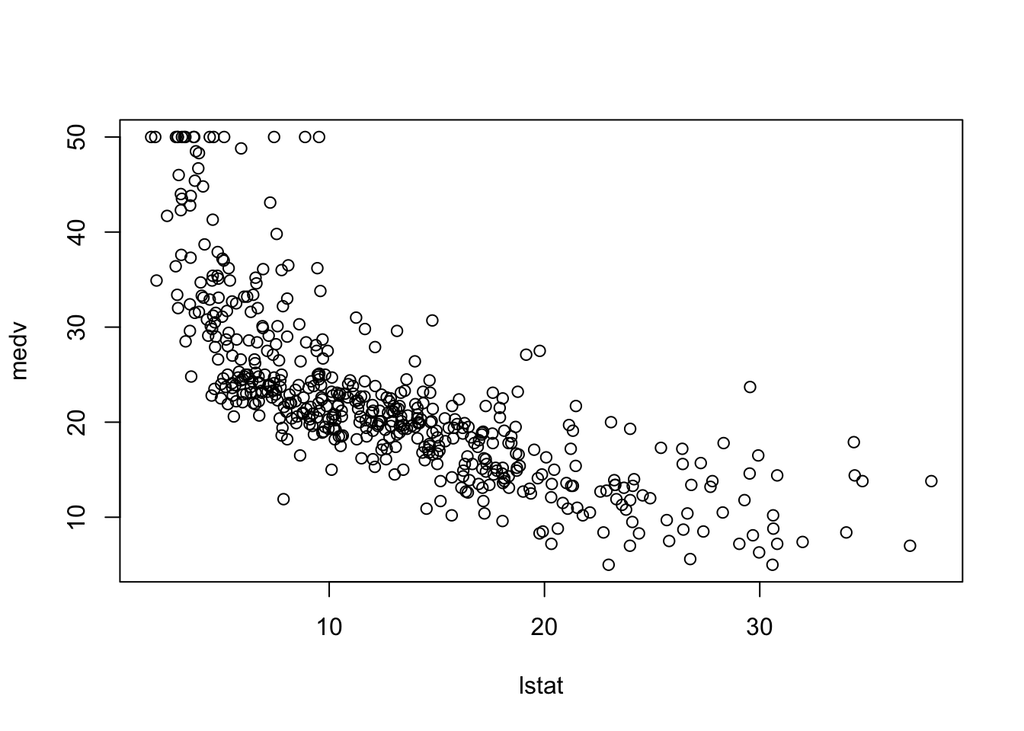

```r
Boston %$% plot(lstat, medv)
```

# Simple Linear Regression:

```r
# mdl <- lm(medv ~ lstat, data = Boston) # old fashioned
mdl <- Boston %$% lm(medv ~ lstat)
```

There are 12 components inside a fitted model:

```r
mdl %>% names()
```

```
##  [1] "coefficients"  "residuals"     "effects"       "rank"
##  [5] "fitted.values" "assign"        "qr"            "df.residual"
##  [9] "xlevels"       "call"          "terms"         "model"
```

```r
mdl$xlevels # a record of the levels of the factors used in fitting
mdl$df.residual # degree of freedom
```

[output not shown]

```r
mdl %>% summary()
```

```
##
## Call:
## lm(formula = medv ~ lstat)
##
## Residuals:
##     Min      1Q  Median      3Q     Max
## -15.168  -3.990  -1.318   2.034  24.500
##
## Coefficients:
##             Estimate Std. Error t value            Pr(>|t|)
## (Intercept) 34.55384    0.56263   61.41 <0.0000000000000002 ***
## lstat       -0.95005    0.03873  -24.53 <0.0000000000000002 ***
## ---
## Signif. codes:  0 '***' 0.001 '**' 0.01 '*' 0.05 '.' 0.1 ' ' 1
##
## Residual standard error: 6.216 on 504 degrees of freedom
## Multiple R-squared:  0.5441, Adjusted R-squared:  0.5432
## F-statistic: 601.6 on 1 and 504 DF,  p-value: < 0.00000000000000022
```

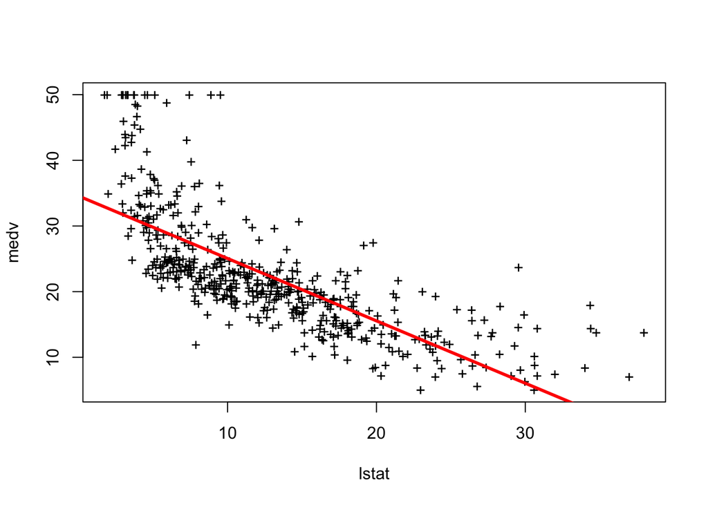

```r
Boston %$% plot(lstat, medv, pch = "+")
abline(mdl, lwd = 3, col = "red")
```

## Validation Plots

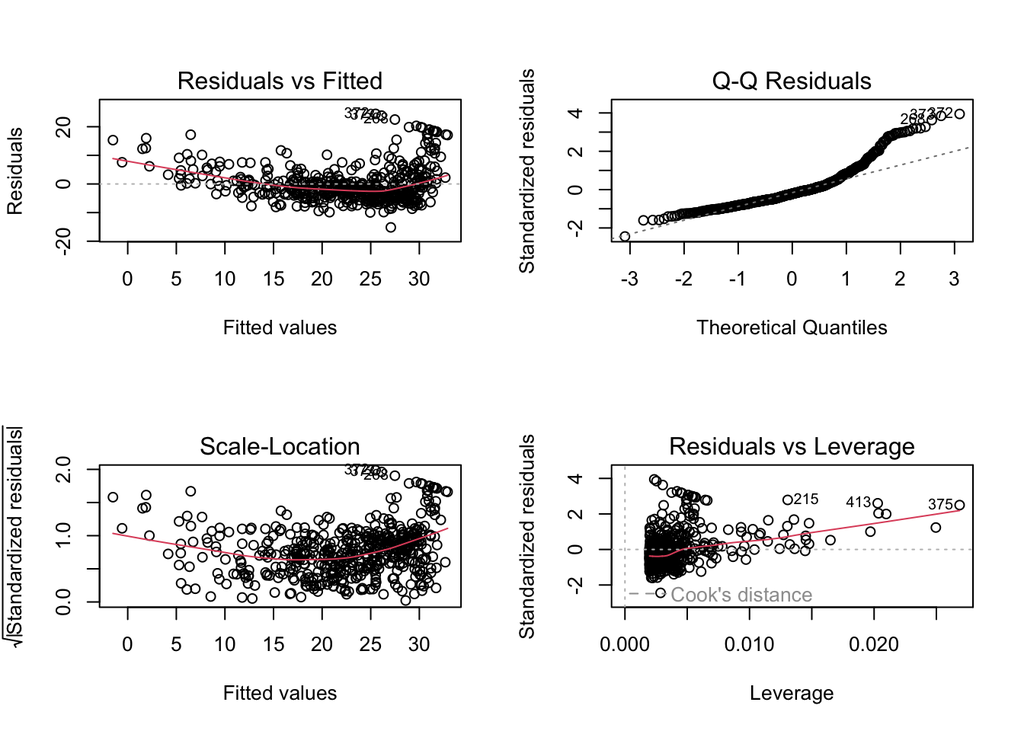

```r
par(mfrow = c(2, 2))
plot(mdl)
```

```r
# qnorm((1 - 0.5) / 506) = -3.09
# qnorm((506 - 0.5) / 506) = 3.09
```

### Residule vs. Fitted

- Whether linearity holds. This is indicated by the mean residual value for every fitted value region being close to 0. In R this is indicated by the red line being close to the dashed line.
- Whether homoskedasticity holds, i.e. the variance is the same. The spread of residuals should be approximately the same across the x-axis.
- Whether there are outliers. This is indicated by some ‘extreme’ residuals that are far from the rest.

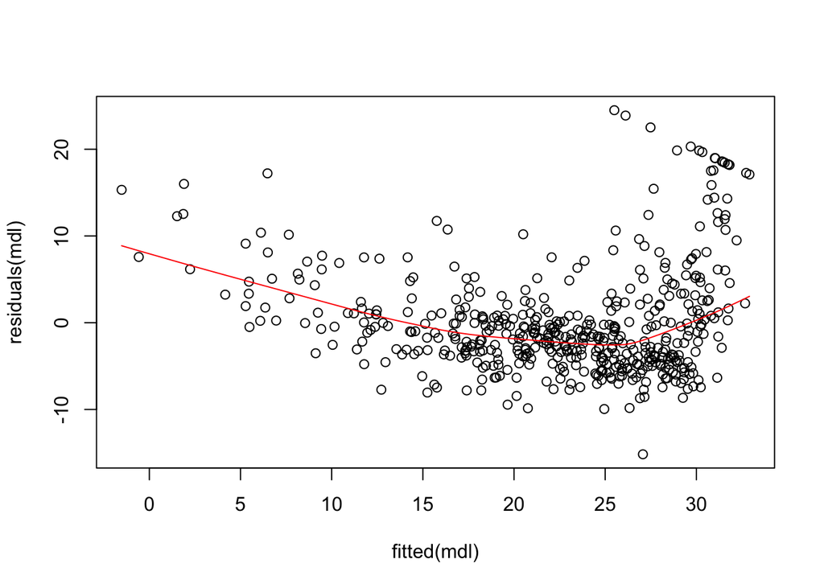

Residual vs Prediction

```r
plot(fitted(mdl), residuals(mdl))
lines(lowess(mdl %>% fitted(), mdl %>% residuals()),
  col = "red"
)
```

### QQ Plot

- on the x-axis are the theoretical quantiles of a standard normal
- For the y-axis, consider the empirical distribution function of the standardized residuals

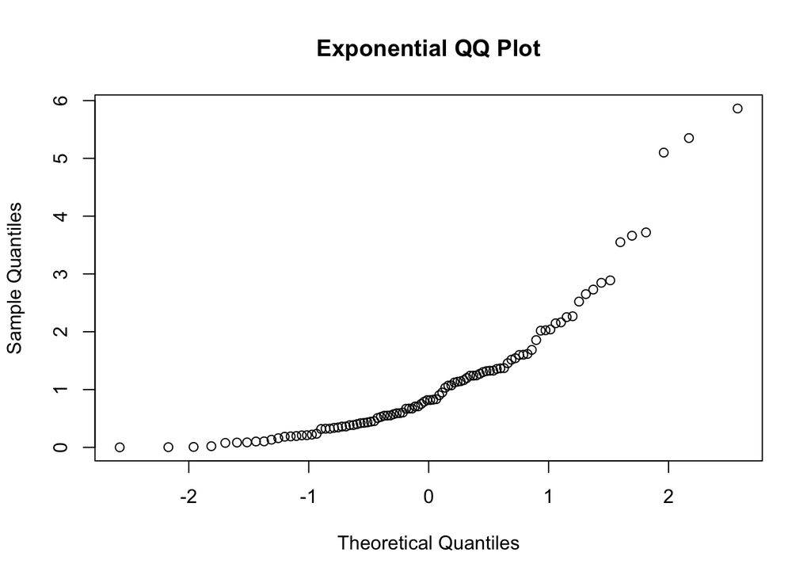

```r
x <- rexp(100)
qqnorm(x, main = "Exponential QQ Plot")
```

### Scale vs. Location

- diagnostic plot commonly used to assess the assumption of homoscedasticity (i.e., equal variances)

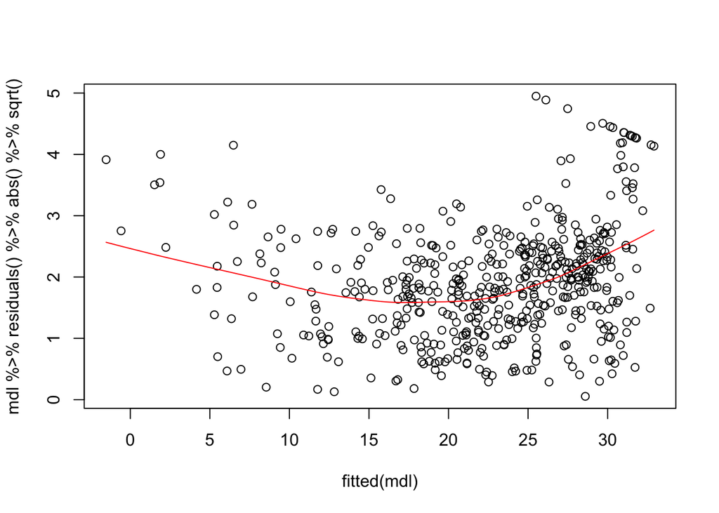

Scale-Location

```r
plot(fitted(mdl), mdl %>% residuals() %>% abs() %>% sqrt())
lines(lowess(fitted(mdl), mdl %>% residuals() %>% abs() %>% sqrt()),
  col = "red"
)
```

- square root of the absolute values of the residuals (y-axis) against the fitted values (x-axis).
- assumptions of homoscedasticity
  - met: the points in the plot should form a horizontal band with no discernible pattern.
  - otherwise: it suggests that the variance of the errors is not constant across the range of the independent variable(s). In this case, it may be necessary to consider a different model or transformation of the dependent variable to improve the model fit.
- Red line help visualize any patterns that may exist.
  - If it deviates from a horizontal line, it suggests that there is a problem with homoscedasticity.

### Residuals vs. Leverage

Also known as Cook’s distance plot, is a diagnostic plot commonly used to assess the influence of each observation on the regression model

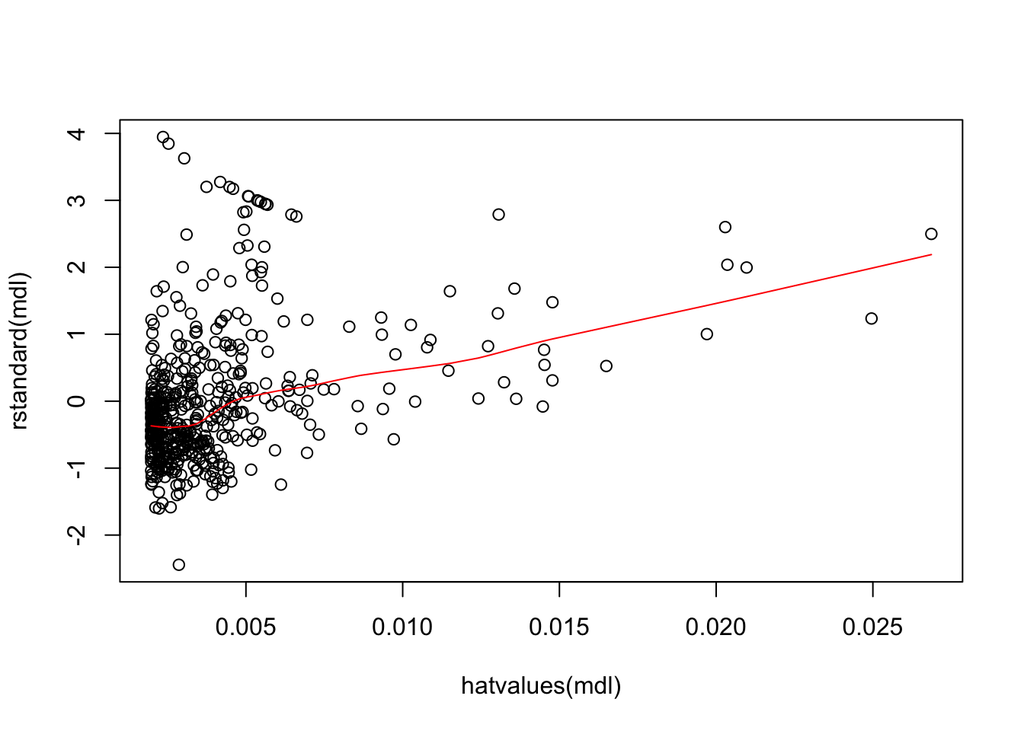

```r
plot(hatvalues(mdl), rstandard(mdl))
lines(lowess(mdl %>% hatvalues(), mdl %>% rstandard()),
  col = "red"
)
```

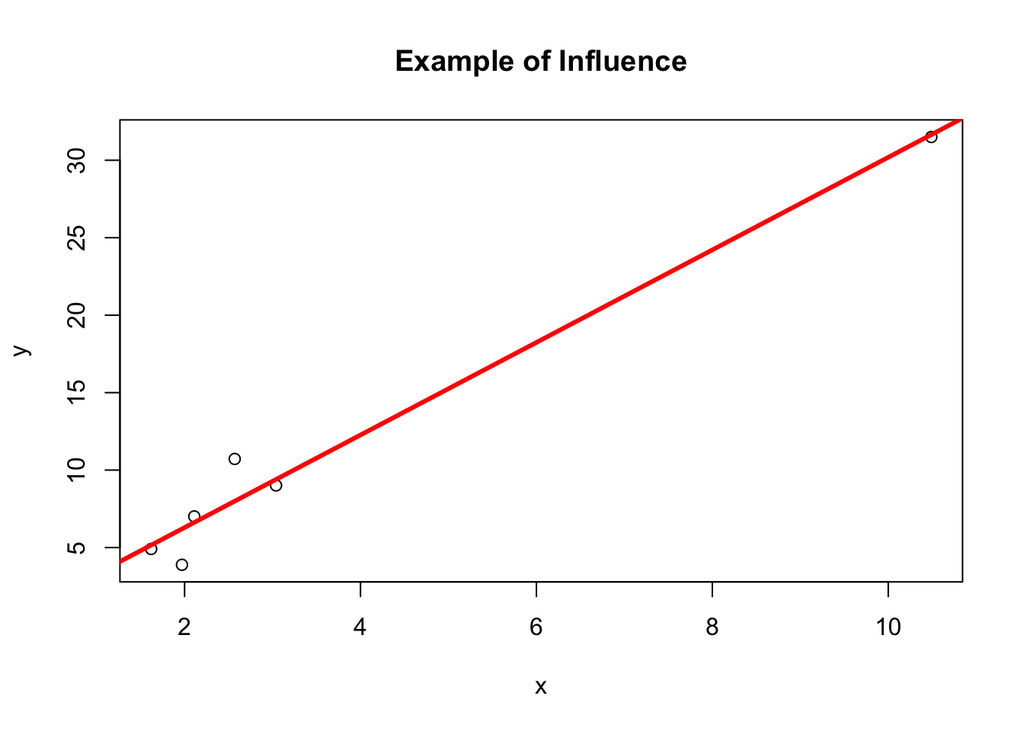

Influence Values of Observations:

```
##         1         2         3         4         5         6
## 0.2369945 0.2069278 0.2146682 0.1862838 0.1727746 0.9823511
```

# Multiple Linear Regression

```r
mdl2 <- Boston %$% lm(medv ~ lstat + age)
mdl2 %>% summary()
```

```
##
## Call:
## lm(formula = medv ~ lstat + age)
##
## Residuals:
##     Min      1Q  Median      3Q     Max
## -15.981  -3.978  -1.283   1.968  23.158
##
## Coefficients:
##             Estimate Std. Error t value             Pr(>|t|)
## (Intercept) 33.22276    0.73085  45.458 < 0.0000000000000002 ***
## lstat       -1.03207    0.04819 -21.416 < 0.0000000000000002 ***
## age          0.03454    0.01223   2.826              0.00491 **
## ---
## Signif. codes:  0 '***' 0.001 '**' 0.01 '*' 0.05 '.' 0.1 ' ' 1
##
## Residual standard error: 6.173 on 503 degrees of freedom
## Multiple R-squared:  0.5513, Adjusted R-squared:  0.5495
## F-statistic:   309 on 2 and 503 DF,  p-value: < 0.00000000000000022
```

```r
mdl3 <- lm(medv ~ ., data = Boston)
mdl3 %>% summary()
```

```
##
## Call:
## lm(formula = medv ~ ., data = Boston)
##
## Residuals:
##     Min      1Q  Median      3Q     Max
## -15.595  -2.730  -0.518   1.777  26.199
##
## Coefficients:
##                Estimate  Std. Error t value             Pr(>|t|)
## (Intercept)  36.4594884   5.1034588   7.144    0.000000000003283 ***
## crim         -0.1080114   0.0328650  -3.287             0.001087 **
## zn            0.0464205   0.0137275   3.382             0.000778 ***
## indus         0.0205586   0.0614957   0.334             0.738288
## chas          2.6867338   0.8615798   3.118             0.001925 **
## nox         -17.7666112   3.8197437  -4.651    0.000004245643808 ***
## rm            3.8098652   0.4179253   9.116 < 0.0000000000000002 ***
## age           0.0006922   0.0132098   0.052             0.958229
## dis          -1.4755668   0.1994547  -7.398    0.000000000000601 ***
## rad           0.3060495   0.0663464   4.613    0.000005070529023 ***
## tax          -0.0123346   0.0037605  -3.280             0.001112 **
## ptratio      -0.9527472   0.1308268  -7.283    0.000000000001309 ***
## black         0.0093117   0.0026860   3.467             0.000573 ***
## lstat        -0.5247584   0.0507153 -10.347 < 0.0000000000000002 ***
## ---
## Signif. codes:  0 '***' 0.001 '**' 0.01 '*' 0.05 '.' 0.1 ' ' 1
##
## Residual standard error: 4.745 on 492 degrees of freedom
## Multiple R-squared:  0.7406, Adjusted R-squared:  0.7338
## F-statistic: 108.1 on 13 and 492 DF,  p-value: < 0.00000000000000022
```

```r
mdl4 <- lm(medv ~ . - age, data = Boston)
mdl4 %>% summary()
```

```
##
## Call:
## lm(formula = medv ~ . - age, data = Boston)
##
## Residuals:
##      Min       1Q   Median       3Q      Max
## -15.6054  -2.7313  -0.5188   1.7601  26.2243
##
## Coefficients:
##               Estimate Std. Error t value             Pr(>|t|)
## (Intercept)  36.436927   5.080119   7.172   0.0000000000027155 ***
## crim         -0.108006   0.032832  -3.290             0.001075 **
## zn            0.046334   0.013613   3.404             0.000719 ***
## indus         0.020562   0.061433   0.335             0.737989
## chas          2.689026   0.859598   3.128             0.001863 **
## nox         -17.713540   3.679308  -4.814   0.0000019671100076 ***
## rm            3.814394   0.408480   9.338 < 0.0000000000000002 ***
## dis          -1.478612   0.190611  -7.757   0.0000000000000503 ***
## rad           0.305786   0.066089   4.627   0.0000047505389684 ***
## tax          -0.012329   0.003755  -3.283             0.001099 **
## ptratio      -0.952211   0.130294  -7.308   0.0000000000010992 ***
## black         0.009321   0.002678   3.481             0.000544 ***
## lstat        -0.523852   0.047625 -10.999 < 0.0000000000000002 ***
## ---
## Signif. codes:  0 '***' 0.001 '**' 0.01 '*' 0.05 '.' 0.1 ' ' 1
##
## Residual standard error: 4.74 on 493 degrees of freedom
## Multiple R-squared:  0.7406, Adjusted R-squared:  0.7343
## F-statistic: 117.3 on 12 and 493 DF,  p-value: < 0.00000000000000022
```

# Non-linear Transformations of the Predictors

**Reciprocal** as an example:

```r
mdl5 <- Boston %$% lm(medv ~ I(1 / lstat))
mdl5 %>% summary()
```

```
##
## Call:
## lm(formula = medv ~ I(1/lstat))
##
## Residuals:
##     Min      1Q  Median      3Q     Max
## -24.839  -2.979  -0.520   2.333  28.213
##
## Coefficients:
##             Estimate Std. Error t value            Pr(>|t|)
## (Intercept)  11.8342     0.4373   27.06 <0.0000000000000002 ***
## I(1/lstat)   94.8510     3.1994   29.65 <0.0000000000000002 ***
## ---
## Signif. codes:  0 '***' 0.001 '**' 0.01 '*' 0.05 '.' 0.1 ' ' 1
##
## Residual standard error: 5.558 on 504 degrees of freedom
## Multiple R-squared:  0.6356, Adjusted R-squared:  0.6348
## F-statistic: 878.9 on 1 and 504 DF,  p-value: < 0.00000000000000022
```

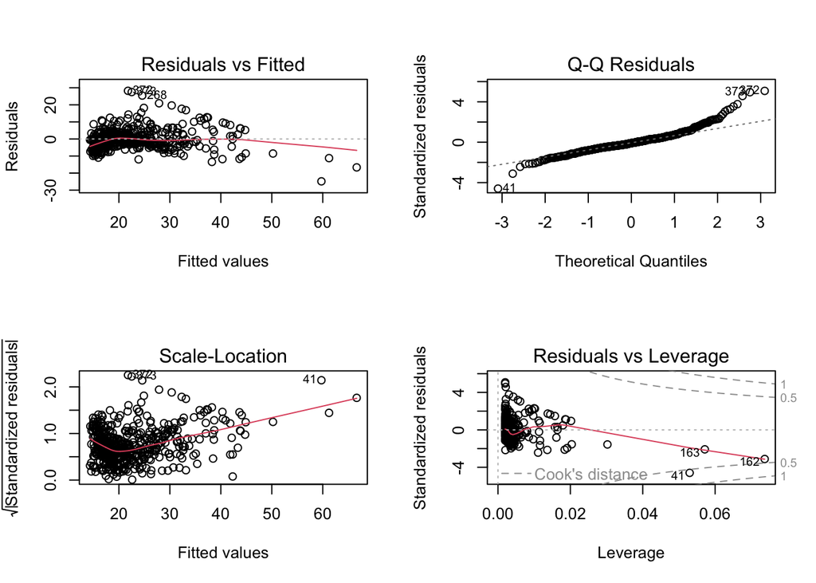

```r
par(mfrow = c(2, 2))
plot(mdl5)
```

```r
mdl6 <- Boston %$% lm(medv ~ I(1 / lstat))
mdl6 %>% summary()
```

```
##
## Call:
## lm(formula = medv ~ I(1/lstat))
##
## Residuals:
##     Min      1Q  Median      3Q     Max
## -24.839  -2.979  -0.520   2.333  28.213
##
## Coefficients:
##             Estimate Std. Error t value            Pr(>|t|)
## (Intercept)  11.8342     0.4373   27.06 <0.0000000000000002 ***
## I(1/lstat)   94.8510     3.1994   29.65 <0.0000000000000002 ***
## ---
## Signif. codes:  0 '***' 0.001 '**' 0.01 '*' 0.05 '.' 0.1 ' ' 1
##
## Residual standard error: 5.558 on 504 degrees of freedom
## Multiple R-squared:  0.6356, Adjusted R-squared:  0.6348
## F-statistic: 878.9 on 1 and 504 DF,  p-value: < 0.00000000000000022
```

# Reference

- https://boostedml.com/2019/03/linear-regression-plots-how-to-read-a-qq-plot.html